# Autumn Summative 2023

Lecturer: Philip Leftwich, Module: UEA BIO 5023Y

# 1. Outline

| Module code | 5023Y |
| --- | --- |
| Item number | 002 |
| Data visualisation | Brief write-up |
| Weighting | 30% of module |

You are being provided with a fake dataset on COVID-19 linelist data[^1]. As a group you must submit a report that uses this data to create an outbreak situation report (maximum two pages) that addresses any topics or trends that you deem relevant to inform an audience of public health and medical responders.

# 2. Summative guidance

- This assessment is due **on or before: 3pm 21st December.**
- You will work in groups of three or four to produce your situational report. Using the data provided to draw insights into topics or trends of interest to public health and medical officials and communicate these clearly to the intended audience
- Produce ONE incredible data figure **per person** - these may contain annotations, labels, arrows if they aid communication.
- Include any necessary explanatory text to accompany your report - this should be kept to the absolute minimum.
- Produce one **group report** of your figures and any explanatory text as html or pdf
- Produce an **individual** reflective report on your role within the group

## Guidance on project management

- Decide on your group membership, designate one person as project co-ordinator.
- To avoid Git conflicts - each person should work on their *own* R scripts, with one person assembling the final report, one person organising the [README](https://www.freecodecamp.org/news/how-to-write-a-good-readme-file/) etc. (with input from the whole group).
- Each set up your own RStudio Project in the **5023Y workspace**
- Start by working in an R script build your script as you go - you can edit and change as you progress - make regular commits to GitHub
- The **best** way to avoid merge conflicts is to **Always** start a session by pulling *from* GitHub, and **always** end a session by pushing *to* Github.
- *Read this* on workflow[^2]
- Make sure all required libraries are called *first* in the script
  - library() *goes in the script*
  - install.packages(““) *NEVER goes in the script*
- Data tidying - check file has imported correctly, is there missing data? are there missing values? is it tidy? Are the data types correct?
- Each R file can have its own tidying script, or you can agree on a common pipeline to be used by all.
- Work together to explore the data and agree on insights/topics for communication
- Each R script you have made can be used as a source file for an Rmarkdown file.
- Clearly indicate which member of the group produced each data visual
- Please indicate whether you wish to be marked for the report as a whole, or for figures to be marked individually.

## Guidance on data visuals

This is **not** a figure in a lab report - so titles, annotations, labelling, highlights etc. are all perfectly valid if they enhance the figure. This is a stand-alone piece, imagine you might present this on a poster, or use it as an information post on Instagram!

- It should have a clear take-home message, remember titles and short captions are often the most well retained part of a data visual, so make this count!
- This is for a general audience, so consider the types of geoms you will use *carefully*
- Don’t overload the graph with too much information
- Focus on how you will make the important elements of the chart standout - colour, annotations, etc?
- Get inspired here are some useful links - but do your own research - be inspired by others and imitate[^3]!!
- Use colour and text - but be responsible and make it accessible [^4]
- Work effectively as a team so that your figures tie together

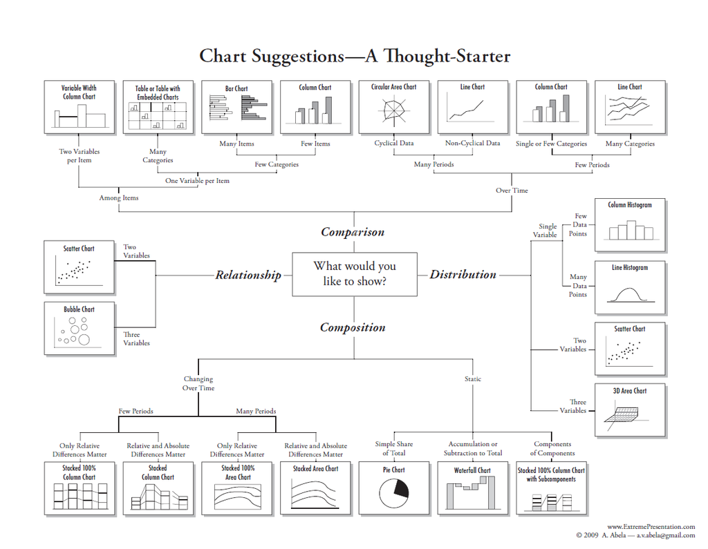

## Guidance on reflective report

Write your reflective report separately to your group project work. No more than 1000 words.

Critically reflect upon the role you have played during the project. In your observations, comment upon the team dynamic, the role you have played and how performance could be improved in your group next time. Make sure to include information on how and when meetings were organised and communication was organised.

# 3. Hand in

The following should be part of your final project:

A Github project that contains:

- R scripts (with code comments) which successfully reproduces the figures in the reports.
- A saved png file of your ggplot data visuals
- An Rmd file that sources your data visual and where you will include your write-up and any suitable references
- Tidy and well organised subfolders
- A useful README

Blackboard handin:

- A knitted **pdf** output of your .rmd file. **This is the file you will hand in via Blackboard.**
- A reflective report on your group work
- **HAND IN - 21st DECEMBER**

# 4. Regulations and extensions

You should be familiar with University Regulations on:

- [Plagiarism](https://my.uea.ac.uk/departments/learning-and-teaching/students/academic-cycle/regulations-and-discipline/plagiarism-awareness)
- How to submit work to [Blackboard](https://my.uea.ac.uk/departments/learning-technology/students/submitting-an-assignment)
- [Submission regulations](https://my.uea.ac.uk/departments/learning-and-teaching/students/academic-cycle/coursework/submission-guide) (Including information on word counts and late penalties)
- [Extenuating Circumstances](https://my.uea.ac.uk/departments/learning-and-teaching/students/support/extenuating-circumstances) If you need help meeting your deadlines.
- **AI policy** - Where the School of Biological Sciences suspects a student (or group of students) of unauthorised and/or undeclared use of AI tools in an assessment submission, all responsible for the submission will be invited by the teaching team for a recorded discussion where you will get the chance to discuss your work. Following the discussion, the recording alongside the submission in question may be sent to the Plagiarism Officer for further investigation (as part of the procedures presented in the University’s, “Plagiarism and Collusion Policy 23/24”). If the student (or group of students) fails to attend the discussion, the case will be sent to the Plagiarism Officer for further investigation. https://www.uea.ac.uk/about/university-information/governance/policies-and-regulations/general-regulations/university-policy-on-plagiarism-and-collusion

# 5. Mark scheme

Marking criteria

[output not shown]

# 6. Help

- Try google and the helpful links in Essential Reading *first*
- Check the discussion board and/or start a thread

## Essential reading

- [Rstudio cheatsheets](https://rstudio.com/resources/cheatsheets/)
- [Beautiful plotting in R - Cedric Scherer](https://cedricscherer.netlify.app/2019/08/05/a-ggplot2-tutorial-for-beautiful-plotting-in-r/)
- [Fundamentals of Data Vizualization - Claus Wilke](https://clauswilke.com/dataviz/)
- [The GGplot2 book](https://ggplot2-book.org/)
- [From Data to Viz](https://www.data-to-viz.com/)
- [GGplot extensions](https://exts.ggplot2.tidyverse.org/)

# 7. Appropriate use of AI

Please consult the below on appropriate/allowable uses of AI. I have tried to be fair and set use cases that ultimately benefit you and your learning. While AI platforms often can produce simple code quickly, ultimately this prevents your ability to learn and understand your code. In my experience they often fail to write more complex code, but if you shortcut the fundamentals you won’t be able to do this either. In addition code suggestions are often inefficient, and won’t follow the way I have taught you to code - in short it will be reasonably obvious if ChatGPT wrote your code. By contrast if you cannot debug something, it may be able to quickly find your errors or help you write comments - these assists don’t prevent you learning.

Please declare any usage as outline above.

| Area | Use case | Allowed? | Reasons |
| --- | --- | --- | --- |
| Writing | Create writing from scratch (ChatGPT, Bard) | No | Writing developed from scratch would be plagiarism (not your words) and reduces opportunities for critical thinking |
|  | Review, summarise or synthesis literature | No | Synthesising literature with AI reduces opportunities for critical thinking and may contain errors mistakes and biases |
|  | Edit, refine or improve writing | Yes | Many exisiting tools can suggest prompts to help with structure and flow of any writing |
|  | Spelling and grammar | Yes | Overlaps with grammar assist tools - always allowed |
| Coding | Create code from scratch (ChatGPT) | No | Prevents opportunities to learn essential coding skills, often provides incorrect or inefficient code |
|  | Debug, annotate or improve code | Yes | Can assist learning and help spot errors quickly or aid in adding notes to code written by the user |

[^1]: A line list is a table that contains key information about each case in an outbreak, with each row representing a case and each column representing a variable such as demographic, clinical and epidemiologic information (e.g. risk factors and exposures)(https://www.cdc.gov/csels/dsepd/ss1978/lesson2/section1.html)
[^2]: (https://r4ds.had.co.nz/workflow-projects.html)
[^3]: (https://medium.economist.com/charting-new-territory-7f5afb293270) (https://www.consultantsmind.com/2019/11/09/economist-graphs/)
[^4]: (https://depictdatastudio.com/how-to-tell-a-story-with-data-titles-subtitles-annotations-dark-light-contrast-and-selective-labeling/)(https://datajournalism.com/read/longreads/accessible-data-visualisation)